# Lab 5: Species distribution modeling (process-based)

Your name

2024-02-13

### **Learning Objectives**

- Produce and interpret a process-based species distribution model
- Evaluate the impacts of climate stress in shaping a species’ distribution
- Compare and contrast model predictions in space and time
- Practice conducting a sensitivity analysis
- Apply custom functions and raster calculations in R

### **Grading Rubric**

Most of your grade will be for effort - i.e., that you did your best to follow instructions and to answer questions. Each lab is worth 30 pts, so divide this number by the total number of questions to estimate the approximate number of points per question. Points may be deducted for errors in code, not following instructions, or answering questions incorrectly.

### **Instructions**

There are a set of questions associated with each exercise below that you must complete either during class or on your own time. Record answers to the questions **within** the Markdown (`.Rmd`) file and record your name on line 2. Once you’re done with the lab, knit the R markdown file as a Word document (`.docx`) within RStudio by clicking the `Knit` button found in the toolbar (look for a ball of yarn with a needle sticking out of it) and selecting `Knit to Word`. Ignore any warning messages that pop up in the Console during knitting. Submit the `.Rmd` **and** the `.docx` files on Canvas.

### **Introduction**

The [Degree-Day, establishment Risk, and Pest event maps (DDRP) platform](https://uspest.org/caps/) uses a process-based modeling approach in which degree-days and temperature stress are calculated daily and accumulate over time to model phenology and climatic suitability, respectively. DDRP requires gridded daily minimum and maximum temperature data (`tmin` and `tmax`, respectively) for a time frame of interest, as well as a species parameter file that has information on the species’ temperature requirements for development and survival. Model products include maps of the predicted potential distribution (climate-based risk of establishment), number of generations, and dates of phenological events. Note: this lab presents an older and pared down version of DDRP. The code for DDRP that is used at USPest.org is available on [GitHub](https://github.com/bbarker505/ddrp_v2).

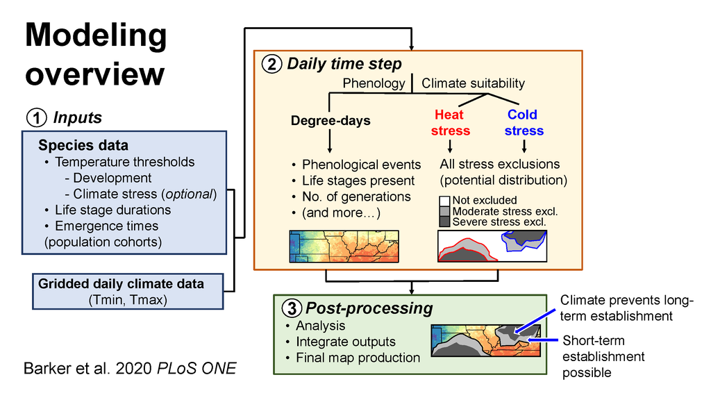

An overview of the DDRP modeling process

In this lab, we are focusing on DDRP’s process-based approach to modeling climatic suitability, which shares some features with the [CLIMEX platform](https://www.hearne.software/Software/CLIMEX-DYMEX/Editions), but it uses a daily time step and can accept climate data at any temporal and spatial resolution [(Barker et al. 2020)](https://doi.org/10.1371/journal.pone.0244005). Cold and heat stress accumulation occurs during the daily time step and is similar to the modeling of degree-days for development, except that temperature stress thresholds and daily `tmin` and `tmax` data are used to accumulate temperature stress units. The extent of the difference between the threshold and temperature will influence how many stress units are calculated for any given day.

DDRP then determines whether total accumulations for a given day exceed the moderate or severe cold and heat stress limits of a species, which provides two levels of exclusion (i.e., moderate vs. severe stress exclusion) at any given location.

For an invasive species, areas that are not excluded by either moderate or severe temperature stress by DDRP are part of the potential distribution and therefore at highest risk of establishment because of increased population survival. Moderate stress may inhibit long-term establishment, with a high probability that short-term establishment could occur during favorable years, whereas areas under severe stress would likely prevent even short-term (one complete year) establishment.

As robust data to test this assumption are lacking for most species, using two levels of climate stress would at least provide a way to represent uncertainty for estimating the probability of establishment, as several sources of uncertainty and error can bias climatic suitability model predictions.

### **Model Functions**

First we define several custom functions that we need for the DDRP model. All raster outputs are plotted using custom functions in the `Lab5_plotting_funcs.R` script. These were included in a separate file to avoid taking up a lot of space for this lab assignment. You can import R scripts into R using the `source()` function.

```r
# Import plotting functions
source(here("Lab5_SDMs_process_based", "Lab5_plotting_funcs.R"))

# Functions for calculating DDs and climate stress
#### Cond: if then else rasters (conditional) ####
Cond <- function(condition, trueValue, falseValue){
  return(condition * trueValue + (!condition)*falseValue)
}

#### Average DD Calc method ((tmax + tmin)/2 - LDT) but with ####
#    horizontal (substitution) upper threshold:
AvgDD <- function(tmax, tmin, LDT, UDT) {
  return(Cond(tmax < LDT, 0,
              Cond(tmin > UDT, 0,
                   Cond(tmax > UDT, (UDT + tmin)/2 - LDT,
                        Cond((tmax + tmin)/2 - LDT < 0, 0,
                             (tmax + tmin)/2 - LDT)))))
}
```

#### **Model Settings and Parameters**

We’ll demonstrate the modeling approaching using the false codling moth (FCM), *Thaumatotibia leucotreta*. FCM is a pest of more than 100 host plants, including all *Citrus* spp. and more than 40 other crops of economic importance in the US including corn, cotton, grapes, peaches, eggplant, and peppers. Its potential economic impact rating is “High” owing to its highly polyphagous habits and its potential ability to thrive in many climates in the US. The life cycle of FCM is shown below.

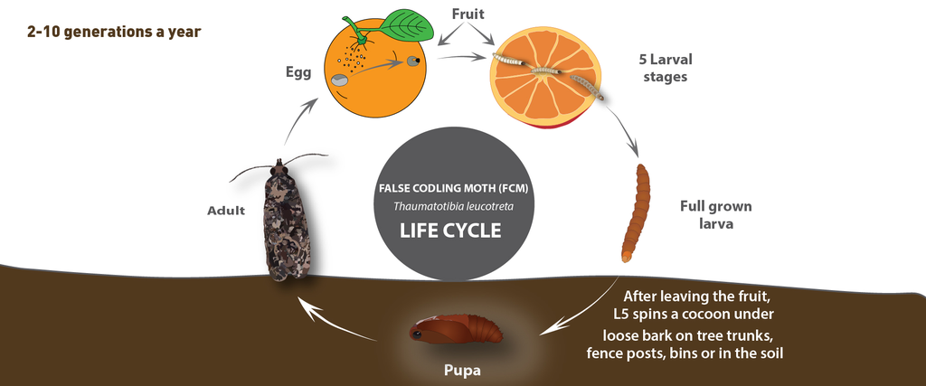

Source: https://www.biobee.com

Prior to running the DDRP model, we specify the directories for input climate data and model outputs. For exercises below, you will need to change the year (`yr`, `spp`, `output_dir`, and `coldstress_units_max1`).

For now, we will run the model for FCM for `2011` using default model parameters.

```r
#### User Settings - CHANGE HERE
spp <- "FCM"
LDT <- 11.7
UDT <- 38
yr <- "2011"

# Directory Locations - change output_dir for sensitivity analyses
# REMEMBER to change the last folder for the output directory (output_dir)
# coldstress_units_max1 = 49 is "csu_max1_49"
# coldstress_units_max1 = 63 is "csu_max1_63"
prism_dir <- here("Lab5_SDMs_process_based", "PRISM", yr)
output_dir <- here("Lab5_SDMs_process_based", "outputs", spp, yr, "default")

#### Pest Specific, Multiple Life Stage Phenology Model Parameters:
#LDT = lower development threshold, temp at which growth = 0
#DD = degree days, number of cumulative heat units to complete that lifestage
# Params for False codling moth, Thaumatotibia leucotreta, in Degrees Celsius
eggLDT <- LDT
larvaeLDT <- LDT
pupaeLDT <- LDT
adultLDT <- LDT
eggUDT <- UDT
larvaeUDT <- UDT
pupaeUDT <- UDT
adultUDT <- UDT

# Degree-day requirements for each stage
eggDD <- 71
larvaeDD <- 155
pupaeDD <- 175
adultDD <- 83

# Temperature exclusion threshold and accum units parameters
# Changes max1 values for sensitivity tests (49 and 63) below
coldstress_threshold  <- 0  # cold stress threshold - default is 0
coldstress_units_max1 <- 35  # "most" all die once reached - default is 35
coldstress_units_max2 <- 125  # all die once reached
heatstress_threshold   <- 40   # heat stress threshold
heatstress_units_max1  <- 75   # "most" all die once reached
heatstress_units_max2  <- 150  # all die once reached
```

The code chunk below imports and processes the gridded `tmin` and `tmax` data, which were derived from the [PRISM database](https://www.prism.oregonstate.edu/). PRISM data have been aggregated to a ~16 km<sup>2</sup> resolution to make DDRP run faster. The code also creates empty rasters (templates) for storing results of the model.

```r
# Weather inputs and outputs
vars <- c("tmin", "tmax")
fls_list <- c("tminfiles", "tmaxfiles")

# Get raster files for each temperature variable
for (i in 1:length(vars)) {

  # List files by variable (pattern)
  fl_pat <- glob2rx(paste0("*PRISM_", vars[i], "*.tif$*"))
  fls <- list.files(path = prism_dir, pattern = fl_pat, full.names = TRUE)
  assign(fls_list[i], fls)
}

# Extract date from temperature files using regex pattern matching
dats <- unique(regmatches(tminfiles, regexpr(pattern = "[0-9]{8}",
                                             text = tminfiles)))

## Create blank template from a temp file
# This template is used for cropping the temperature (tmin, tmax) rasters
template <- rast(tminfiles[1]) # Template
template[!is.na(template)] <- 0
extent <- ext(template)

## Initialize all tracking rasters as zero with the template
# Phenology
DDtotal     <- template
DDaccum     <- template
Lifestage   <- template
NumGen      <- template

# Cold/heat stress units
coldmask         <- template  # binary mask for daily cold stress units
coldstress       <- template  # count of daily cold stress units
coldunitsCUM     <- template  # cumulative cold sterss units
coldstressTHRESH <- coldstress_threshold # mask for cold stress units threshold
coldstressMAX1   <- coldstress_units_max1 # use for max cold stress before mortality??
coldstressMAX2   <- coldstress_units_max2 # use for uncertainty zone max cold stress before mortality??
coldEXCL          <- template  # EXCL map for cold stress
heatmask          <- template  # binary mask for daily heat stress units
heatstress        <- template  # use for heat stress units
heatunitsCUM      <- template  # cumulative heat stress units
heatstressTHRESH  <- heatstress_threshold # mask for heatstress units threshold
heatstressMAX1    <- heatstress_units_max1 # use for max heat before mortality?
heatstressMAX2    <- heatstress_units_max2 # use for max heat before mortality?
heatEXCL          <- template  # EXCL map for heat stress
allEXCL           <- template  # EXCL map for combined stresses (cold,heat,later: moisture)
```

### **Run the Model**

The `for` loop below iterates over each day of the year and calculates degree-day accumulation, number of completed generations, life stages present, cold stress accumulation, heat stress accumulation, areas excluded by cold stress, areas excluded by heat stress, and areas excluded by all climate stresses. The `eval` argument is set to `FALSE` so that this step will be skipped when you knit the R Markdown file.

NOTE: this step can be **SLOW** - be patient. Anytime you change parameter values, you must run the code chunks above before proceeding to this step.

```r
# Accumulate degree days and reclass cells to NA with temperature exclusion
# NA for exclusion means that DD accum cannot occur anymore with incomplete
# generation development and no oviposition to next generation.
for (d in dats) {

    #print(d)

    # Read in that day's PRISM raster files
    tmin_pattern <- paste("(PRISM_tmin_)(.*)(", d,")(.*)(.tif)$", sep="")
    tmin_fl <- list.files(prism_dir, pattern=tmin_pattern, full.names=TRUE)
    tmax_pattern <- paste("(PRISM_tmax_)(.*)(", d,")(.*)(.tif)$", sep="")
    tmax_fl <- list.files(prism_dir, pattern=tmax_pattern, full.names=TRUE)

    # Rasters
    tmin <- rast(tmin_fl)
    tmax <- rast(tmax_fl)

    #Create stage specific lifestage binary rasters
    #Limits operations to a mask for cells that are in that lifestage
    #This is what allows for pixel by pixel tracking of what lifestage
    # that cell is in
    LS0 <- Lifestage == 0
    LS1 <- Lifestage == 1
    LS2 <- Lifestage == 2
    LS3 <- Lifestage == 3

    # Cold stress
    coldmask <- tmin < coldstressTHRESH  # make todays cold mask
    coldstress <- coldmask * abs(coldstressTHRESH - tmin) # compute todays cold stress DDs
    coldunitsCUM <- coldunitsCUM + coldstress
    # ASSUME NEW -2=severe -1=mod 0=none throughout
    coldEXCL <- Cond(coldunitsCUM >= coldstressMAX2,-2,Cond(coldunitsCUM >= coldstressMAX1,-1,0))

    # Heat stress
    heatmask <- tmax > heatstressTHRESH  # make todays heat mask
    heatstress <- heatmask * abs(tmax - heatstressTHRESH) # compute todays heat stress DDs
    heatunitsCUM <- heatunitsCUM + heatstress
    heatEXCL <- Cond(heatunitsCUM >= heatstressMAX2,-2,Cond(heatunitsCUM >= heatstressMAX1,-1,0))

    # All climate stress (cold + heat)
    allEXCL <- Cond((coldEXCL == 0) & (heatEXCL == 0),0,
               Cond((coldEXCL == -1) & (heatEXCL >= -1),-1,
               Cond((coldEXCL >= -1) & (heatEXCL == -1),-1,-2)))

    # Loop through each life stage
    for (i in 1:4) {
      if (i==1){
         #developmental degree days  (zero values for temps below LDT)
         dd0 <- AvgDD(tmax,tmin,eggLDT,eggUDT)
         dd0 <- dd0 * LS0
         #Accumulate degree days
         DDaccum <- DDaccum + dd0
         #Calculate lifestage progression
         progress0 <- (DDaccum >= eggDD) * LS0
         Lifestage <- Lifestage + progress0
         #Reset the DDaccum cells to zero for cells that progressed to next lifestage
         progress0 <- (DDaccum >= eggDD) * LS0
         DDaccum <- Cond(progress0 == 0, DDaccum, 0)

      } else if (i == 2) {
         # developmental degree days
         dd1 <- AvgDD(tmax,tmin,larvaeLDT,larvaeUDT)
         dd1 <- dd1 * LS1
         # Accumulate degree days
         DDaccum <- DDaccum + dd1
         # Accumulate total degree days
         DDtotal <- DDtotal + dd1
         # Calculate lifestage progression
         progress1 <- (DDaccum >= larvaeDD) * LS1
         Lifestage <- Lifestage + progress1
         # Reset the DDaccum cells to zero for cells that progressed to next lifestage
         progress1 <- (DDaccum >= larvaeDD) * LS1
         DDaccum <- Cond(progress1 == 0, DDaccum, 0)

      } else if (i == 3) {
         # developmental degree days
         dd2 <- AvgDD(tmax,tmin,pupaeLDT,pupaeUDT)
         dd2 <- dd2 * LS2
         DDaccum <- DDaccum + dd2
         # Calculate lifestage progression
         progress2 <- (DDaccum >= pupaeDD) * LS2
         Lifestage <- Lifestage + progress2
         # Reset the DDaccum cells to zero for cells that progressed to next lifestage
         progress2 <- (DDaccum >= pupaeDD) * LS2
         DDaccum <- Cond(progress2 == 0, DDaccum, 0)

      } else { # adult stage, or time to 50% oviposition
         # developmental degree days
         dd3 <- AvgDD(tmax,tmin,adultLDT,adultUDT)
         dd3 <- dd3 * LS3
         # Accumulate degree days
         DDaccum <- DDaccum + dd3
         # Reset lifestage progression to 0 for oviposition
         progress3 <- (DDaccum >= adultDD) * LS3
         Lifestage <- Cond(progress3 == 1,0, Lifestage)
         # Reset the DDaccum cells to zero for cells that progressed to next lifestage
         DDaccum <- Cond(progress3 == 1,0, DDaccum)
         # Increment NumGen + 1
         NumGen <- NumGen + progress3
         }
    }
}
```

### **Save and Plot Model Outputs**

Model outputs are rasters. We’ll use the `writeRaster()` function in `terra` to save each output.

```r
# Save raster outputs
writeRaster(DDtotal, paste0(output_dir, "/", spp, "_Total_DDs_", yr, ".tif"), overwrite=TRUE)
writeRaster(NumGen, paste0(output_dir, "/", spp, "Num_Gens_", yr, ".tif"), overwrite=TRUE)
writeRaster(coldunitsCUM, paste0(output_dir, "/", spp, "_Cold_Stress_Units_", yr, ".tif"),  overwrite=TRUE)
writeRaster(coldEXCL, paste0(output_dir, "/", spp, "_Cold_Stress_Excl_", yr, ".tif"), overwrite=TRUE)
writeRaster(heatunitsCUM, paste0(output_dir, "/", spp, "_Heat_Stress_Units_", yr, ".tif"), overwrite=TRUE)
writeRaster(heatEXCL, paste0(output_dir, "/", spp, "_Heat_Stress_Excl_", yr, ".tif"), overwrite=TRUE)
writeRaster(allEXCL, paste0(output_dir, "/", spp, "_All_Stress_Excl_", yr, ".tif"), overwrite=TRUE)
```

Next, we’ll plot the rasters using the `PlotMap` function (custom function). Plots are saved as image (`.png`) files.

```r
# Plot raster outputs and save plots
PlotMap(coldEXCL, yr, type = "Cold stress exclusion")
PlotMap(heatEXCL, yr, type = "Heat stress exclusion")
PlotMap(allEXCL, yr, type = "All stress exclusion")
PlotMap(DDtotal, yr, type = "Total DDs")
PlotMap(NumGen, yr, type = "Number of generations")
PlotMap_stress(coldunitsCUM, year = yr, type = "Cold stress accumulation",
               max1 = coldstressMAX1, max2 = coldstressMAX2)
PlotMap_stress(heatunitsCUM, year = yr, type = "Heat stress accumulation",
               max1 = heatstressMAX1, max2 = heatstressMAX2)
```

Next, we will calculate the area (km<sup>2</sup>) excluded by climate stresses and the area where FCM was predicted to complete at least one generation. The `freq()` function in `terra` will give the count of cells for each integer value in the map. All results are multiplied by `16` to approximate the area (one cell = ~16 km<sup>2</sup>)

```r
# Area of each raster cell is ca. 16 km2
cell_size <- 16

# Total area excluded by cold stress
area_excl_sev <- freq(allEXCL,1,-1)
area_excl_mod <- freq(allEXCL,1,-2)
area_not_excl <- freq(allEXCL,1, 0)

# Total area in exclusion zones (both climate stresses)
excl_CS <- coldEXCL < 0
area_excl_CS <- freq(excl_CS,1,1)
excl_HS <- heatEXCL < 0
area_excl_HS <- freq(excl_HS,1,1)

# Total area where at least 1 generation completes over the year
area_NumGen <- freq(NumGen,1)
area_NumGen_Gt1 <- area_NumGen %>%
  filter(value > 0) %>%
  summarize(count = sum(count))

# Combine results
areas_all <- data.frame(
  "type" = c("all_excl_sev", "all_excl_mod", "not_excl", "CS_excl", "HS_excl", "Gt1_gen"),
  "area" = c(area_excl_sev$count, area_excl_mod$count, area_not_excl$count, area_excl_CS$count,
             area_excl_HS$count,area_NumGen_Gt1$count) * cell_size,
  "cs_thres" = rep(c(coldstress_threshold), 6),
  "csu_max1" = rep(c(coldstress_units_max1), 6))

# Save the results
# Document
fl_name <- paste0(spp, "_areas_", yr, ".csv")
write.csv(areas_all, paste0(output_dir, "/", fl_name), row.names = FALSE)
```

#### **Exercise 1: Modeling Voltinism and Climate Suitability for FCM**

**(1)** For your run for `2011`, describe **AND** interpret any relationships that you see between:  
(a) climate stress accumulations and areas excluded by climate stresses.  
(b) climate stress accumulations and degree-day accumulations.  
(c) degree-day accumulations and voltinism (number of generations per year).

*Response*:

**(2)** Run the model for `2016`, and then compare and contrast maps and tables to those for `2011`. Change the `yr` (year) value in the Model Settings. You can import the tables using the `read.csv()` function, or simply open the file via the “Files/Plots/etc.” pane in RStudio. Then answer these questions:  
(a) Report total areas excluded by cold and stresses for each year. In which year did FCM experience greater range-limiting climate stresses overall?  
(b) Which areas were excluded by climate stresses in both years?  
(c) Why is there variation in climate stress exclusions and voltinism among years?

*Response*:

**(3)** Compare your model outputs for FCM with those at USPest.org. Your results should be similar, but not identical, because you’re using climate data for different years and the above DDRP code may be slightly different. Also, this lab doesn’t integrate phenology and climate suitability maps since this requires more code complexity. The maps at the link below depict FCM’s voltinism and potential distribution (areas not excluded by cold and heat stress). The third map integrates the first maps.  
https://uspest.org/CAPS/FCM_cohorts/FCM_NumGen_20241231.png  
https://uspest.org/CAPS/FCM_cohorts/FCM_All_Stress_Excl_20241231.png  
https://uspest.org/CAPS/FCM_cohorts/FCM_NumGen_Excl2_20241231.png

What are some potential applications of producing **near real-time** forecasts of phenology and climate suitability for FCM and other invasive pests?

*Response*:

**(4)** Based on estimations of the potential distribution and voltinism for FCM for three different years, where might you prioritize efforts for surveillance of this invasive pest? Why?

*Response*:

#### **Exercise 2: Sensitivity Analysis for FCM Model Parameters**

We will conduct a sensitivity analysis to evaluate the impact of variation in the cold stress threshold (`coldstress_threshold`) and moderate cold stress limit (`coldstress_units_max1`) on the total area excluded by cold stress, which represents the potential distribution of FCM. Areas excluded by moderate cold stress may represent zones of “uncertainty” - i.e., we’re not sure if the species can establish in those areas or not.

**IMPORTANT NOTE:** Remember to keep all other parameter values and climate inputs constant for this analysis. You only change one parameter at a time.

For simplicity, we will only test two additional values for each parameter. Results were already produced for the `coldstress_threshold`. You need to run the analysis using the two `coldsress_units_max1` values. Remember to change the output directory name appropriately. See the comments below.

```r
# Use climate data for 2016
yr <- 2016

## ***This part is already DONE***
# Cold stress threshold - default is 0
# Test -0.4C and -0.8C (-40%)
# Leave all other parameters default
# Output dir: cs_thres_neg0.4C
# coldstress_threshold <- -0.4 # value 1
# Output dir: cs_thres_neg0.8
# coldstress_threshold <- -0.8 # value 2

## **YOU NEED TO DO** - change the modeling settings above
# "cold_stress_max1" sensitivity tests: default is 35
# Test 49 and 63 units (+40%)
# Output dir: csu_max1_49
# coldstress_units_max1 <- 49 # value 1
# Output dir: csu_max1_63
# coldstress_units_max1 <- 63 # value 2
```

After completing the model runs, import the CSV files that contain area estimates. All CSV files are found by searching a pattern, and then stored in a list by applying the `read.csv()` function.

```r
# Import outputs
csv_fls <- list.files(here("Lab5_SDMs_process_based", "outputs", "FCM", "2016"),
                      pattern = ".csv$", recursive = TRUE, full.names = TRUE)

# Name files by the subfolder name
# Count number of "/" in path name
# "str_split_fixed" splits up strings by a character (e.g., "/")
num_splits <- str_count(csv_fls[1], "/")
fl_nams <- str_split_fixed(csv_fls, "[/]", num_splits + 1)[,num_splits]

# Apply "read.csv()" to import data from all files
# Name the files using the previously defined names
all_areas_list <- lapply(csv_fls, read.csv)
names(all_areas_list) <- fl_nams
str(all_areas_list)
```

```
## List of 5
##  $ cs_thres_neg0.4:'data.frame': 6 obs. of  4 variables:
##   ..$ type    : chr [1:6] "all_excl_sev" "all_excl_mod" "not_excl" "CS_excl" ...
##   ..$ area    : int [1:6] 14768 83168 17952 92048 6032 96224
##   ..$ cs_thres: num [1:6] -0.4 -0.4 -0.4 -0.4 -0.4 -0.4
##   ..$ csu_max1: int [1:6] 35 35 35 35 35 35
##  $ cs_thres_neg0.8:'data.frame': 6 obs. of  4 variables:
##   ..$ type    : chr [1:6] "all_excl_sev" "all_excl_mod" "not_excl" "CS_excl" ...
##   ..$ area    : int [1:6] 14464 82048 19376 90592 6032 96224
##   ..$ cs_thres: num [1:6] -0.8 -0.8 -0.8 -0.8 -0.8 -0.8
##   ..$ csu_max1: int [1:6] 35 35 35 35 35 35
##  $ csu_max1_49    :'data.frame': 6 obs. of  4 variables:
##   ..$ type    : chr [1:6] "all_excl_sev" "all_excl_mod" "not_excl" "CS_excl" ...
##   ..$ area    : int [1:6] 12624 84496 18768 91232 6032 96224
##   ..$ cs_thres: int [1:6] 0 0 0 0 0 0
##   ..$ csu_max1: int [1:6] 49 49 49 49 49 49
##  $ csu_max1_63    :'data.frame': 6 obs. of  4 variables:
##   ..$ type    : chr [1:6] "all_excl_sev" "all_excl_mod" "not_excl" "CS_excl" ...
##   ..$ area    : int [1:6] 10144 84496 21248 88672 6032 96224
##   ..$ cs_thres: int [1:6] 0 0 0 0 0 0
##   ..$ csu_max1: int [1:6] 63 63 63 63 63 63
##  $ default        :'data.frame': 6 obs. of  4 variables:
##   ..$ type    : chr [1:6] "all_excl_sev" "all_excl_mod" "not_excl" "CS_excl" ...
##   ..$ area    : int [1:6] 14848 84496 16544 93536 6032 96224
##   ..$ cs_thres: int [1:6] 0 0 0 0 0 0
##   ..$ csu_max1: int [1:6] 35 35 35 35 35 35
```

Now we’ll combine all data in the list using the `bind_rows()` function in `dplyr` and then subset results produced using default parameters to get the initial model output value (i.e., area not excluded by climate stress). Note: I added `1` to cold stress threshold values because the equation below won’t work when `0` is the denominator.

```r
# Area excluded by cold stress increases as cold_stress_threshold increases (decreasing potential distribution)
# Make data frame from list, subset results for area (km2) excluded by cold stress
all_areas_dfs <- bind_rows(all_areas_list, .id = "param") %>%
  filter(type == "not_excl") %>%
  mutate(cs_thres = (cs_thres + 1))

# Get default results (coldstress_threshold = 0, coldstress_units_max1 = 35)
# Output (area not excluded by cold stress) is used in below equations
# Area not excluded = 16544
default_not_excl <- all_areas_dfs %>%
  filter(param == "default")
default_not_excl
```

```
##     param     type  area cs_thres csu_max1
## 1 default not_excl 16544        1       35
```

Finally, we’ll use the equation of Essington (2021) to estimate the proportional change in the model output to the proportional change in each model parameter value. I have already produced results for the cold stress threshold (`coldstress_threshold`). You need to run the model after changing moderate cold stress limits (`coldstress_units_max1`). Follow the instructions in the comments below.

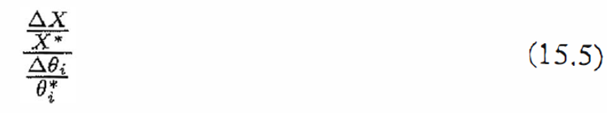

Source: Essington 2021, Ch. 15.2.1

```r
# Calculate proportional change in area not excluded for each model output
# I added 1 to the cold stress threshold values because dividing by 0 results in infinity
# Areas not excluded by climae stress should increase as cold stress threshold decreases
sens_cs_thres <- all_areas_dfs %>%
   filter(grepl("thres", param)) %>%
   mutate(chng_output = (area - 16544) / 16544,
          chng_param = (cs_thres - 1) / 1) %>%
   mutate(prop_chng = chng_output/chng_param)
sens_cs_thres
```

```
##             param     type  area cs_thres csu_max1 chng_output chng_param
## 1 cs_thres_neg0.4 not_excl 17952      0.6       35  0.08510638       -0.4
## 2 cs_thres_neg0.8 not_excl 19376      0.2       35  0.17117988       -0.8
##    prop_chng
## 1 -0.2127660
## 2 -0.2139749
```

```r
# RUN THE MODEL using "coldstress_units_max1" = 49 and 63 (coldstress_threshold = 0)
# Then uncomment the code block below
# Area not excluded by climate stress should increase as max1 increases
sens_csu_max1 <- all_areas_dfs %>%
   filter(grepl("max1", param)) %>%
   mutate(chng_output = (area - 16544) / 16544,
          chng_param = (csu_max1 - 35) / 35) %>%
   mutate(prop_chng = chng_output/chng_param)
sens_csu_max1
```

```
##         param     type  area cs_thres csu_max1 chng_output chng_param prop_chng
## 1 csu_max1_49 not_excl 18768        1       49   0.1344294        0.4 0.3360735
## 2 csu_max1_63 not_excl 21248        1       63   0.2843327        0.8 0.3554159
```

```r
# Combine the results
sens_all <- bind_rows(sens_cs_thres, sens_csu_max1)
sens_all
```

```
##             param     type  area cs_thres csu_max1 chng_output chng_param
## 1 cs_thres_neg0.4 not_excl 17952      0.6       35  0.08510638       -0.4
## 2 cs_thres_neg0.8 not_excl 19376      0.2       35  0.17117988       -0.8
## 3     csu_max1_49 not_excl 18768      1.0       49  0.13442940        0.4
## 4     csu_max1_63 not_excl 21248      1.0       63  0.28433269        0.8
##    prop_chng
## 1 -0.2127660
## 2 -0.2139749
## 3  0.3360735
## 4  0.3554159
```

**(5)** Interpret the results of the perturbation analyses. Specifically, how did similar increases to parameter value affect changes in the area not excluded by climate stress (i.e., the potential distribution)? Which parameter (`coldstress_threshold` vs. `coldtress_units_max1`) does the output appear to be more sensitive to?

*Response*:

#### **Exercise 3: Modeling Additional Species**

Pick a different species and run the DDRP model. Follow these instructions:  
(a) Go to https://uspest.org/CAPS.  
(b) Pick one of the 15 species at this website (not FCM).  
(c) Find the model parameters in the `metadata.txt` file in the `Logs_metadata` subdirectory.  
(d) Create a folder with the species abbreviation in the `output` folder for this lab.  
(e) Find the corresponding values for: species abbrev, species name, thresholds, DD requirements, and climate suitability parameter values in the file and change them in the appropriate code chunk above.  
(f) Run the model using climate data for `2011` and `2016`.

**(6)** Compare the model outputs for your chosen species to those produced for FCM for the same years.

In your answer, describe how:  
(a) differences in their climate stress parameter values may explain differences in their potential distribution.  
(b) differences in their lower developmental threshold and degree-day requirements may explain differences in voltinism.  
(c) whether their changes in the voltinism and the potential distribution exhibited similar shifts between `2011` and `2016`.

*Response*:

**(7)** Describe at least one limitation of the DDRP modeling approach **AND** what you might change to address this limitation. For example, this might include adding additional climate factors, modifying the model structure, or something else.

*Response*:

**(8)** Discuss your overall results from the species distribution modeling exercises.

*Response*: